# Jawaban Latihan - Regresi dengan Peubah Lag

Latihan 1 (Distributed Lag) & Latihan 2 (ARDL)

Muhammad Daffa Fadhilah Athif

## 0.1 *Packages*

```r
#install.packages("dLagM")
#install.packages("dynlm")
#install.packages("MLmetrics")
library(dLagM)
library(dynlm)
library(MLmetrics)
library(lmtest)
library(car)
```

# 1 Latihan 1 : Distributed Lag (Pangsa Pasar vs Harga)

Data pangsa pasar (Y) dan harga (X) pasta gigi selama 20 periode.

## 1.1 Impor Data

```r
data1 <- data.frame(
  Period = 1:20,
  Y = c(3.63,4.20,3.33,4.54,2.89,4.87,4.90,5.29,6.18,7.20,
        7.25,6.09,6.80,8.65,8.43,8.29,7.18,7.90,8.45,8.23),
  X = c(0.97,0.95,0.99,0.91,0.98,0.90,0.89,0.86,0.85,0.82,
        0.79,0.83,0.81,0.77,0.76,0.80,0.83,0.79,0.76,0.78)
)
str(data1)
```

```
## 'data.frame':    20 obs. of  3 variables:
##  $ Period: int  1 2 3 4 5 6 7 8 9 10 ...
##  $ Y     : num  3.63 4.2 3.33 4.54 2.89 4.87 4.9 5.29 6.18 7.2 ...
##  $ X     : num  0.97 0.95 0.99 0.91 0.98 0.9 0.89 0.86 0.85 0.82 ...
```

```r
data1
```

| Period | Y | X |
| --- | --- | --- |
| 1 | 3.63 | 0.97 |
| 2 | 4.20 | 0.95 |
| 3 | 3.33 | 0.99 |
| 4 | 4.54 | 0.91 |
| 5 | 2.89 | 0.98 |
| 6 | 4.87 | 0.90 |
| 7 | 4.90 | 0.89 |
| 8 | 5.29 | 0.86 |
| 9 | 6.18 | 0.85 |
| 10 | 7.20 | 0.82 |

[output cut: 10 more lines]

## 1.2 Pembagian Data

Data dibagi menjadi *train* (75%, periode 1-15) dan *test* (25%, periode 16-20), mengikuti alur pada modul.

```r
train1 <- data1[1:15, ]
test1  <- data1[16:20, ]

train1.ts <- ts(train1)
test1.ts  <- ts(test1)
data1.ts  <- ts(data1)
```

## 1.3 Model Koyck

Model Koyck mengasumsikan pengaruh $X$ terhadap $Y$ meluruh secara geometris seiring bertambahnya lag, sehingga direpresentasikan lewat $Y_{t-1}$.

```r
model.koyck1 <- koyckDlm(x = train1$X, y = train1$Y)
summary(model.koyck1)
```

```
##
## Call:
## "Y ~ (Intercept) + Y.1 + X.t"
##
## Residuals:
##     Min      1Q  Median      3Q     Max
## -0.9997 -0.3171  0.0652  0.2586  1.1063
##
## Coefficients:
##             Estimate Std. Error t value Pr(>|t|)
## (Intercept)  15.4328    14.7611   1.046    0.318
## Y.1           0.3651     0.5152   0.709    0.493
## X.t         -13.4703    13.8869  -0.970    0.353
##
## Residual standard error: 0.599 on 11 degrees of freedom
## Multiple R-Squared: 0.9037,  Adjusted R-squared: 0.8861
## Wald test: 37.92 on 2 and 11 DF,  p-value: 1.16e-05
##
## Diagnostic tests:
## NULL
##
##                             alpha      beta       phi
## Geometric coefficients:  24.30938 -13.47028 0.3651498
```

```r
AIC(model.koyck1)
```

```
## [1] 30.00231
```

```r
BIC(model.koyck1)
```

```
## [1] 32.55853
```

### 1.3.1 Peramalan & Akurasi

```r
fore.koyck1 <- forecast(model = model.koyck1, x = test1$X, h = 5)
fore.koyck1
```

```
## $forecasts
## [1] 7.734805 7.076847 7.375405 7.888531 7.806494
##
## $call
## forecast.koyckDlm(model = model.koyck1, x = test1$X, h = 5)
##
## attr(,"class")
## [1] "forecast.koyckDlm" "dLagM"
```

```r
mape.koyck1 <- MAPE(fore.koyck1$forecasts, test1$Y)
mape.koyck1
```

```
## [1] 0.05312954
```

```r
GoF(model.koyck1)
```

|  | n | MAE | MPE | MAPE | sMAPE | MASE | MSE | MRAE | GMRAE |
| --- | --- | --- | --- | --- | --- | --- | --- | --- | --- |
| model.koyck1 | 14 | 0.4215632 | -0.01898878 | 0.08448088 | 0.08112884 | 0.4555545 | 0.2818772 | 1.457091 | 0.5463437 |

## 1.4 Regression with Distributed Lag (Lag = 1)

```r
model.dlm1 <- dlm(x = train1$X, y = train1$Y, q = 1)
summary(model.dlm1)
```

```
##
## Call:
## lm(formula = model.formula, data = design)
##
## Residuals:
##     Min      1Q  Median      3Q     Max
## -0.5929 -0.2490 -0.1363  0.3539  0.6775
##
## Coefficients:
##             Estimate Std. Error t value Pr(>|t|)
## (Intercept)   25.779      1.440  17.898 1.75e-09 ***
## x.t          -23.725      2.837  -8.363 4.27e-06 ***
## x.1            0.571      2.901   0.197    0.848
## ---
## Signif. codes:  0 '***' 0.001 '**' 0.01 '*' 0.05 '.' 0.1 ' ' 1
##
## Residual standard error: 0.4179 on 11 degrees of freedom
## Multiple R-squared:  0.9531, Adjusted R-squared:  0.9446
## F-statistic: 111.8 on 2 and 11 DF,  p-value: 4.917e-08
##
## AIC and BIC values for the model:
##        AIC      BIC
## 1 19.92429 22.48052
```

```r
AIC(model.dlm1)
```

```
## [1] 19.92429
```

```r
BIC(model.dlm1)
```

```
## [1] 22.48052
```

```r
fore.dlm1 <- forecast(model = model.dlm1, x = test1$X, h = 5)
fore.dlm1
```

```
## $forecasts
## [1] 7.232201 6.543279 7.509428 8.198350 7.706710
##
## $call
## forecast.dlm(model = model.dlm1, x = test1$X, h = 5)
##
## attr(,"class")
## [1] "forecast.dlm" "dLagM"
```

```r
mape.dlm1 <- MAPE(fore.dlm1$forecasts, test1$Y)
mape.dlm1
```

```
## [1] 0.07181656
```

```r
GoF(model.dlm1)
```

|  | n | MAE | MPE | MAPE | sMAPE | MASE | MSE | MRAE | GMRAE |
| --- | --- | --- | --- | --- | --- | --- | --- | --- | --- |
| model.dlm1 | 14 | 0.3274674 | -0.001197325 | 0.0612012 | 0.06177849 | 0.3538716 | 0.1372238 | 1.490945 | 0.4781451 |

## 1.5 Pencarian *Lag* Optimum

```r
finiteDLMauto(formula = Y ~ X,
              data = data.frame(train1), q.min = 1, q.max = 10,
              model.type = "dlm", error.type = "AIC", trace = TRUE)
```

|  | q - k | MASE | AIC | BIC | GMRAE | MBRAE | R.Adj.Sq | Ljung-Box |
| --- | --- | --- | --- | --- | --- | --- | --- | --- |
| 7 | 7 | 0.00000 | -Inf | -Inf | 0.00000 | 0.00000 | NaN | NaN |
| 8 | 8 | 0.00000 | -Inf | -Inf | 0.00000 | 0.00000 | NaN | NaN |
| 9 | 9 | 0.00000 | -Inf | -Inf | 0.00000 | 0.00000 | NaN | NaN |
| 10 | 10 | 0.00000 | -Inf | -Inf | 0.00000 | 0.00000 | NaN | NaN |
| 6 | 6 | 0.08453 | -4.06421 | -2.28919 | 0.11903 | -0.33129 | 0.97249 | 0.04562035 |
| 3 | 3 | 0.27946 | 14.41990 | 17.32934 | 0.49694 | -0.34334 | 0.95685 | 0.87839563 |
| 5 | 5 | 0.30204 | 15.91911 | 18.33979 | 0.49375 | -0.33012 | 0.89375 | 0.34730411 |
| 4 | 4 | 0.29388 | 16.21356 | 18.99882 | 0.48458 | -0.05971 | 0.94508 | 0.68007694 |
| 1 | 1 | 0.35387 | 19.92429 | 22.48052 | 0.47815 | 1.13162 | 0.94457 | 0.32743011 |
| 2 | 2 | 0.32363 | 20.56206 | 23.38680 | 0.35152 | -0.40855 | 0.94035 | 0.68818708 |

Pencarian AIC memilih lag optimum pada **q = 6**. Model tersebut kemudian diestimasi ulang:

```r
model.dlm1.opt <- dlm(x = train1$X, y = train1$Y, q = 6)
summary(model.dlm1.opt)
```

```
##
## Call:
## lm(formula = model.formula, data = design)
##
## Residuals:
##        1        2        3        4        5        6        7        8
## -0.06257  0.05379  0.06679 -0.05236 -0.03731  0.04871 -0.07404  0.12979
##        9
## -0.07279
##
## Coefficients:
##             Estimate Std. Error t value Pr(>|t|)
## (Intercept)  37.4332     2.7496  13.614   0.0467 *
## x.t         -43.9959     5.1527  -8.538   0.0742 .
## x.1           1.3336     4.4868   0.297   0.8161
## x.2           0.6599     2.9610   0.223   0.8604
## x.3           0.3176     3.5214   0.090   0.9427
## x.4          16.6181     5.4842   3.030   0.2029
## x.5           1.3711     3.0017   0.457   0.7272
## x.6         -13.6131     4.2894  -3.174   0.1943
## ---
## Signif. codes:  0 '***' 0.001 '**' 0.01 '*' 0.05 '.' 0.1 ' ' 1
##
## Residual standard error: 0.2131 on 1 degrees of freedom
## Multiple R-squared:  0.9966, Adjusted R-squared:  0.9725
## F-statistic:  41.4 on 7 and 1 DF,  p-value: 0.1191
##
## AIC and BIC values for the model:
##         AIC       BIC
## 1 -4.064207 -2.289185
```

```r
AIC(model.dlm1.opt)
```

```
## [1] -4.064207
```

```r
BIC(model.dlm1.opt)
```

```
## [1] -2.289185
```

> Catatan: karena jumlah amatan *train* relatif kecil (15 periode), model dengan lag=6 hanya menyisakan sedikit derajat bebas sehingga rawan *overfitting*. Hasil ini tetap ditampilkan karena dipilih murni berdasarkan kriteria AIC, namun perlu kehati-hatian dalam interpretasi maupun generalisasi ke data baru.

### 1.5.1 Peramalan & Akurasi

```r
fore.dlm1.opt <- forecast(model = model.dlm1.opt, x = test1$X, h = 5)
fore.dlm1.opt
```

```
## $forecasts
## [1] 7.728853 6.573892 7.160285 8.510554 8.769298
##
## $call
## forecast.dlm(model = model.dlm1.opt, x = test1$X, h = 5)
##
## attr(,"class")
## [1] "forecast.dlm" "dLagM"
```

```r
mape.dlm1.opt <- MAPE(fore.dlm1.opt$forecasts, test1$Y)
mape.dlm1.opt
```

```
## [1] 0.06368703
```

```r
GoF(model.dlm1.opt)
```

|  | n | MAE | MPE | MAPE | sMAPE | MASE | MSE | MRAE | GMRAE |
| --- | --- | --- | --- | --- | --- | --- | --- | --- | --- |
| model.dlm1.opt | 9 | 0.06646092 | -8.151672e-05 | 0.009854368 | 0.009858763 | 0.08452899 | 0.005044506 | 0.1947309 | 0.1190314 |

```r
akurasi1 <- matrix(c(mape.koyck1, mape.dlm1, mape.dlm1.opt))
row.names(akurasi1) <- c("Koyck", "DLM (q=1)", "DLM (q=6, optimum)")
colnames(akurasi1) <- "MAPE"
akurasi1
```

```
##                          MAPE
## Koyck              0.05312954
## DLM (q=1)          0.07181656
## DLM (q=6, optimum) 0.06368703
```

### 1.6.1 Plot Perbandingan

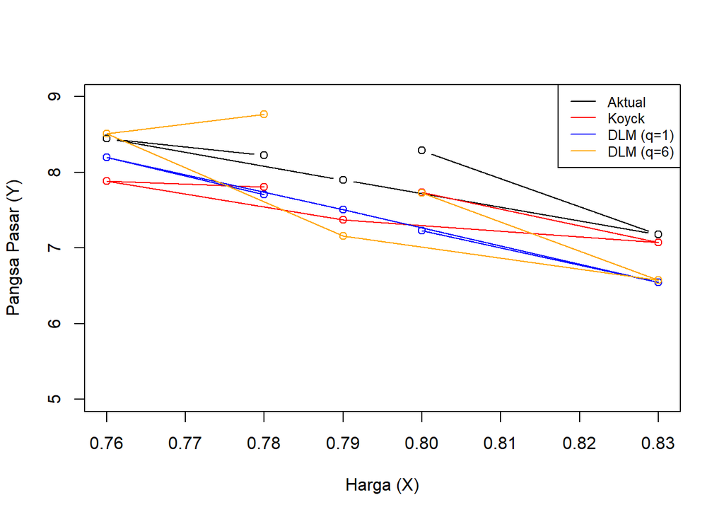

```r
plot(test1$X, test1$Y, type = "b", col = "black", ylim = c(5,9),
     xlab = "Harga (X)", ylab = "Pangsa Pasar (Y)")
points(test1$X, fore.koyck1$forecasts, col = "red");   lines(test1$X, fore.koyck1$forecasts, col = "red")
points(test1$X, fore.dlm1$forecasts, col = "blue");    lines(test1$X, fore.dlm1$forecasts, col = "blue")
points(test1$X, fore.dlm1.opt$forecasts, col = "orange"); lines(test1$X, fore.dlm1.opt$forecasts, col = "orange")
legend("topright", c("Aktual", "Koyck", "DLM (q=1)", "DLM (q=6)"),
       lty = 1, col = c("black","red","blue","orange"), cex = 0.8)
```

# 2 Latihan 2 : ARDL (Sales vs Advertising)

Data tahunan *Sales* (Y) dan *Advertising* (X) periode 1975-2014 (40 tahun).

## 2.1 Impor Data

```r
data2 <- data.frame(
  Year = 1975:2014,
  Y = c(11.7,12.0,12.3,12.8,13.1,13.6,13.9,14.4,14.7,15.3,
        15.5,15.8,16.1,16.6,16.9,16.7,16.9,17.4,17.6,17.9,
        18.0,17.9,18.0,18.2,18.2,18.3,18.6,19.2,19.3,19.5,
        19.2,19.3,19.5,20.0,20.0,19.9,19.8,19.9,20.2,21.0),
  X = c(9.4,9.6,10.0,10.4,10.8,10.9,11.7,12.2,12.5,12.9,
        13.0,13.2,13.8,14.2,14.6,14.4,15.0,15.4,15.7,15.9,
        15.9,16.0,16.3,16.2,16.8,17.3,17.6,18.1,18.3,18.5,
        18.7,18.9,19.2,20.0,20.0,20.3,20.4,21.0,21.5,22.1)
)
str(data2)
```

```
## 'data.frame':    40 obs. of  3 variables:
##  $ Year: int  1975 1976 1977 1978 1979 1980 1981 1982 1983 1984 ...
##  $ Y   : num  11.7 12 12.3 12.8 13.1 13.6 13.9 14.4 14.7 15.3 ...
##  $ X   : num  9.4 9.6 10 10.4 10.8 10.9 11.7 12.2 12.5 12.9 ...
```

## 2.2 Pembagian Data

*Train* = 1975-2004 (30 tahun), *test* = 2005-2014 (10 tahun).

```r
train2 <- data2[1:30, ]
test2  <- data2[31:40, ]

train2.ts <- ts(train2)
test2.ts  <- ts(test2)
data2.ts  <- ts(data2)
```

## 2.3 Model ARDL(p = 1, q = 1)

Sebagai model awal, digunakan ARDL dengan $p=1$ (lag $X$) dan $q=1$ (lag $Y$), mengikuti alur pada modul.

```r
model.ardl2 <- ardlDlm(formula = Y ~ X, data = train2, p = 1, q = 1)
summary(model.ardl2)
```

```
##
## Time series regression with "ts" data:
## Start = 2, End = 30
##
## Call:
## dynlm(formula = as.formula(model.text), data = data)
##
## Residuals:
##       Min        1Q    Median        3Q       Max
## -0.229277 -0.127437  0.009143  0.109228  0.259132
##
## Coefficients:
##             Estimate Std. Error t value Pr(>|t|)
## (Intercept)  1.55786    0.44353   3.512  0.00171 **
## X.t          0.29110    0.13707   2.124  0.04376 *
## X.1         -0.09584    0.16067  -0.596  0.55621
## Y.1          0.74360    0.09964   7.463 8.14e-08 ***
## ---
## Signif. codes:  0 '***' 0.001 '**' 0.01 '*' 0.05 '.' 0.1 ' ' 1
##
## Residual standard error: 0.1576 on 25 degrees of freedom
## Multiple R-squared:  0.9955, Adjusted R-squared:  0.9949
## F-statistic:  1830 on 3 and 25 DF,  p-value: < 2.2e-16
```

```r
AIC(model.ardl2)
```

```
## [1] -19.18177
```

```r
BIC(model.ardl2)
```

```
## [1] -12.34529
```

Hasil uji-t menunjukkan bahwa $X_t$ dan $Y_{t-1}$ signifikan ($p<0{,}05$), sedangkan $X_{t-1}$ tidak signifikan. Model keseluruhan:

$$\hat{Y}_t = 1{,}56 + 0{,}29X_t - 0{,}10X_{t-1} + 0{,}74Y_{t-1}$$

### 2.3.1 Peramalan & Akurasi

```r
fore.ardl2 <- forecast(model = model.ardl2, x = test2$X, h = 10)
fore.ardl2
```

```
## $forecasts
##  [1] 19.72862 19.93768 20.16129 20.53170 20.73047 20.96560 21.14081 21.43616
##  [9] 21.74384 22.09937
##
## $call
## forecast.ardlDlm(model = model.ardl2, x = test2$X, h = 10)
##
## attr(,"class")
## [1] "forecast.ardlDlm" "dLagM"
```

```r
mape.ardl2 <- MAPE(fore.ardl2$forecasts, test2$Y)
mape.ardl2
```

```
## [1] 0.0484832
```

```r
GoF(model.ardl2)
```

|  | n | MAE | MPE | MAPE | sMAPE | MASE | MSE | MRAE | GMRAE |
| --- | --- | --- | --- | --- | --- | --- | --- | --- | --- |
| model.ardl2 | 29 | 0.1238592 | -0.0001484019 | 0.007696613 | 0.007697173 | 0.4281553 | 0.0214047 | 81884782 | 0.7548444 |

## 2.4 Pencarian Orde (p,q) Optimum

```r
model.ardl2.opt <- ardlBoundOrders(data = data.frame(train2), ic = "AIC",
                                    formula = Y ~ X)
model.ardl2.opt
```

```
## $p
##   X
## 1 9
##
## $q
## [1] 5
##
## $Stat.table
##             q = 1      q = 2      q = 3     q = 4      q = 5     q = 6
## p = 1  -17.699638 -15.159785 -11.171253 -12.97933  -9.595366 -13.27011
## p = 2  -15.479841 -13.700376  -9.602500 -11.28856  -8.094541 -11.38500
## p = 3  -12.842321 -12.842321 -11.353394 -12.78397 -10.302797 -12.74830
## p = 4  -10.635346  -8.929704  -8.929704 -12.70373  -9.983369 -12.65121
## p = 5   -9.806117 -13.826706 -13.057325 -13.05733 -11.391142 -15.09657
## p = 6  -10.952036 -11.769321  -9.940426 -13.06169 -13.061688 -14.01520
## p = 7  -16.758977 -26.261218 -24.852544 -25.47848 -24.699579 -24.69958
## p = 8  -17.228470 -37.897273 -36.101045 -37.99830 -36.004045 -40.37030
## p = 9  -15.247022 -25.453391 -37.081485 -47.43756 -52.877759        NA
## p = 10 -16.426957 -25.692234 -33.670479        NA         NA        NA
## p = 11 -24.297308         NA         NA        NA         NA        NA
##             q = 7      q = 8      q = 9     q = 10    q = 11 q = 12 q = 13
## p = 1   -8.733676  -6.780325  -2.406017 -11.832556 -31.13954     NA     NA
## p = 2   -6.791005  -6.094917  -1.950582  -9.840686 -32.26806     NA     NA
## p = 3   -8.116889  -6.050750  -5.212960  -7.840793        NA     NA     NA
## p = 4   -8.021885  -6.468408  -4.559211  -6.112776        NA     NA     NA
## p = 5  -10.474985 -13.381567 -46.224394         NA        NA     NA     NA
## p = 6   -9.433391 -11.477147 -44.228354         NA        NA     NA     NA
## p = 7  -27.814134 -37.722738         NA         NA        NA     NA     NA
## p = 8  -40.370303 -38.812165         NA         NA        NA     NA     NA
## p = 9          NA         NA         NA         NA        NA     NA     NA
## p = 10         NA         NA         NA         NA        NA     NA     NA
## p = 11         NA         NA         NA         NA        NA     NA     NA
##        q = 14 q = 15
## p = 1      NA     NA
## p = 2      NA     NA
## p = 3      NA     NA
## p = 4      NA     NA
## p = 5      NA     NA
## p = 6      NA     NA
## p = 7      NA     NA
## p = 8      NA     NA
## p = 9      NA     NA
## p = 10     NA     NA
## p = 11     NA     NA
##
## $min.Stat
## [1] -52.87776
```

```r
min_p <- c()
for (i in 1:6) {
  min_p[i] <- min(model.ardl2.opt$Stat.table[[i]])
}
q_opt <- which(min_p == min(min_p, na.rm = TRUE))
p_opt <- which(model.ardl2.opt$Stat.table[[q_opt]] ==
                 min(model.ardl2.opt$Stat.table[[q_opt]], na.rm = TRUE))
data.frame("q_optimum" = q_opt, "p_optimum" = p_opt,
           "AIC" = model.ardl2.opt$min.Stat)
```

| q_optimum | p_optimum | AIC |
| --- | --- | --- |
| 1 | 11 | -52.87776 |

```r
model.ardl2.final <- dynlm(Y ~ X + L(Y), data = train2.ts)
summary(model.ardl2.final)
```

```
##
## Time series regression with "ts" data:
## Start = 2, End = 30
##
## Call:
## dynlm(formula = Y ~ X + L(Y), data = train2.ts)
##
## Residuals:
##       Min        1Q    Median        3Q       Max
## -0.241256 -0.124752  0.008004  0.121297  0.272373
##
## Coefficients:
##             Estimate Std. Error t value Pr(>|t|)
## (Intercept)  1.71947    0.34678   4.958 3.75e-05 ***
## X            0.22200    0.07235   3.068  0.00498 **
## L(Y)         0.71154    0.08285   8.588 4.56e-09 ***
## ---
## Signif. codes:  0 '***' 0.001 '**' 0.01 '*' 0.05 '.' 0.1 ' ' 1
##
## Residual standard error: 0.1556 on 26 degrees of freedom
## Multiple R-squared:  0.9954, Adjusted R-squared:  0.995
## F-statistic:  2814 on 2 and 26 DF,  p-value: < 2.2e-16
```

```r
AIC(model.ardl2.final)
```

```
## [1] -20.77194
```

```r
BIC(model.ardl2.final)
```

```
## [1] -15.30276
```

$$\hat{Y}_t = 1{,}72 + 0{,}22X_t + 0{,}71Y_{t-1}$$

Model ini memiliki AIC/BIC lebih rendah (lebih baik) dibanding ARDL(1,1) sekaligus lebih sederhana (parsimoni), sehingga dipilih sebagai kandidat model terbaik.

### 2.4.1 Peramalan & Akurasi Model ARDL(0,1)

Karena diestimasi via `dynlm`, peramalan dilakukan secara manual/rekursif untuk data uji.

```r
coef.final <- coef(model.ardl2.final)
y_prev <- tail(train2$Y, 1)
fore.final <- numeric(nrow(test2))
for (i in seq_len(nrow(test2))) {
  fore.final[i] <- coef.final["(Intercept)"] +
    coef.final["X"] * test2$X[i] +
    coef.final["L(Y)"] * y_prev
  y_prev <- fore.final[i]
}
fore.final
```

```
##  [1] 19.74586 19.96520 20.18786 20.52390 20.76300 20.99973 21.19038 21.45923
##  [9] 21.76152 22.10982
```

```r
mape.ardl2.final <- MAPE(fore.final, test2$Y)
mape.ardl2.final
```

```
## [1] 0.04965051
```

## 2.5 Uji Diagnostik Model Terbaik (ARDL(0,1))

```r
dwtest(model.ardl2.final)     # autokorelasi
```

```
##
##  Durbin-Watson test
##
## data:  model.ardl2.final
## DW = 1.8706, p-value = 0.2357
## alternative hypothesis: true autocorrelation is greater than 0
```

```r
bptest(model.ardl2.final)     # heteroskedastisitas
```

```
##
##  studentized Breusch-Pagan test
##
## data:  model.ardl2.final
## BP = 0.12148, df = 2, p-value = 0.9411
```

```r
shapiro.test(residuals(model.ardl2.final))  # normalitas
```

```
##
##  Shapiro-Wilk normality test
##
## data:  residuals(model.ardl2.final)
## W = 0.95861, p-value = 0.3036
```

- Jika p-value > 0.05 pada `dwtest`/`bptest`/`shapiro.test` di atas → tidak ada autokorelasi/heteroskedastisitas, dan residual berdistribusi normal (asumsi terpenuhi).

## 2.6 Perbandingan Model & Kesimpulan Latihan 2

```r
akurasi2 <- matrix(c(mape.ardl2, mape.ardl2.final))
row.names(akurasi2) <- c("ARDL(1,1)", "ARDL(0,1) - optimum")
colnames(akurasi2) <- "MAPE"
akurasi2
```

```
##                           MAPE
## ARDL(1,1)           0.04848320
## ARDL(0,1) - optimum 0.04965051
```

Kedua model memiliki MAPE yang sangat dekat (di bawah 5%, mengindikasikan akurasi peramalan yang sangat baik), namun **ARDL(0,1)** memiliki AIC/BIC terendah dan struktur yang lebih sederhana (tidak menyertakan lag $X$ yang tidak signifikan). Oleh karena itu, **model ARDL(0,1)**:

$$\hat{Y}_t = 1{,}72 + 0{,}22X_t + 0{,}71Y_{t-1}$$

dipilih sebagai **model ARDL terbaik** untuk memodelkan *Sales* terhadap *Advertising* pada data ini.

### 2.6.1 Plot Perbandingan

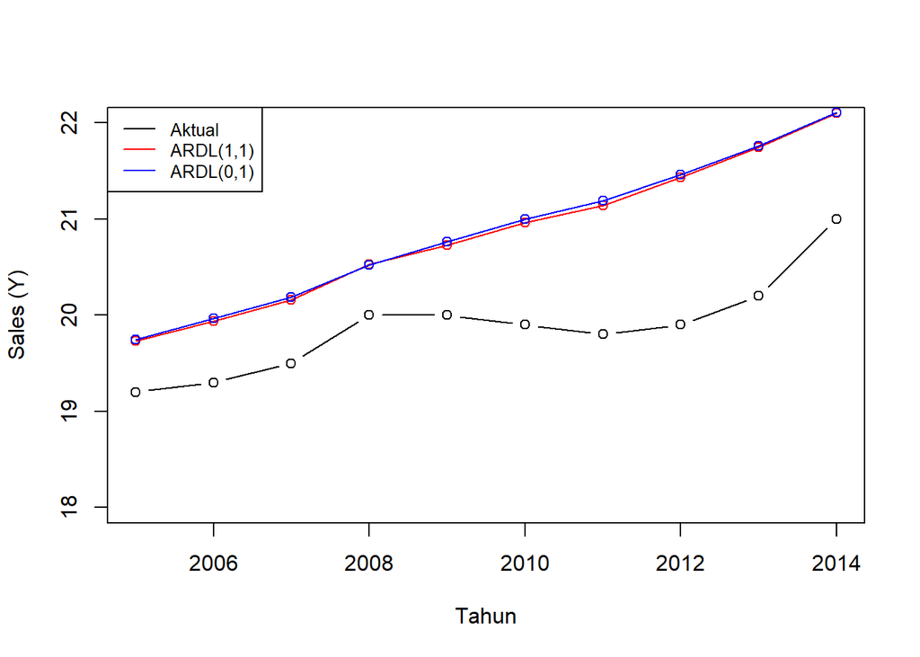

```r
plot(test2$Year, test2$Y, type = "b", col = "black", ylim = c(18,22),
     xlab = "Tahun", ylab = "Sales (Y)")
points(test2$Year, fore.ardl2$forecasts, col = "red");  lines(test2$Year, fore.ardl2$forecasts, col = "red")
points(test2$Year, fore.final, col = "blue");            lines(test2$Year, fore.final, col = "blue")
legend("topleft", c("Aktual", "ARDL(1,1)", "ARDL(0,1)"),
       lty = 1, col = c("black","red","blue"), cex = 0.8)
```